# Convolutional Neural Networks (CNN) - Object Recognition

# Preprocess Data

#### * We need to preprocess our data so that it is easier to feed it to our neural network.

### Scalling both x_train and test

```python
x_train_all =x_train_all / 255.0
```

```python
x_test =  x_test / 255.0
```

```python
y_test
```

```
array([[3],
       [8],
       [8],
       ...,
       [5],
       [1],
       [7]], dtype=uint8)
```

### Creating categorical encoding for the "y " data

```python
# 10 >>> simply means we have 10 classes like we already know (creating the encoding for 10 classes)
y_cat_train_all = to_categorical(y_train_all,10)
```

```python
# 10 >>> simply means we have 10 classes like we already know (creating the encoding for 10 classes)
y_cat_test = to_categorical(y_test,10)
```

```python
y_cat_train_all
```

```
array([[0., 0., 0., ..., 0., 0., 0.],
       [0., 0., 0., ..., 0., 0., 1.],
       [0., 0., 0., ..., 0., 0., 1.],
       ...,
       [0., 0., 0., ..., 0., 0., 1.],
       [0., 1., 0., ..., 0., 0., 0.],
       [0., 1., 0., ..., 0., 0., 0.]])
```

# Creating the Validation dataset

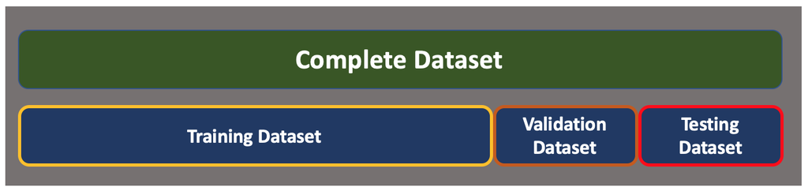

For small data we usually go with: * 60% for Training * 20% Validation * 20% Testing

Only the final selected model gets to see the testing data. This helps us to ensure that we have close to real data in real-world when the model is deployed. Only our best model gets to see our testing dataset. Because it will give us a realistic impression of how our model will do in the real world ___

However, if the dataset is enormous.: * 1% for is used for validation * 1% for is used for testing

```python
VALIDATION_SIZE = 10000
```

```python
# VALIDATION_SIZE = 10,000 as defined above

x_val = x_train_all[:VALIDATION_SIZE]
y_val_cat = y_cat_train_all[:VALIDATION_SIZE]
x_val.shape
```

```
(10000, 32, 32, 3)
```

```python
y_val_cat
```

```
array([[0., 0., 0., ..., 0., 0., 0.],
       [0., 0., 0., ..., 0., 0., 1.],
       [0., 0., 0., ..., 0., 0., 1.],
       ...,
       [0., 1., 0., ..., 0., 0., 0.],
       [0., 1., 0., ..., 0., 0., 0.],
       [0., 0., 0., ..., 0., 0., 0.]])
```

**NEXT:**

```python
x_train = x_train_all[VALIDATION_SIZE:]
y_cat_train= y_cat_train_all[VALIDATION_SIZE:]
```

```python
x_train.shape
```

```
(40000, 32, 32, 3)
```

```python
y_cat_train
```

```
array([[0., 1., 0., ..., 0., 0., 0.],
       [0., 0., 0., ..., 0., 0., 0.],
       [0., 0., 0., ..., 0., 0., 0.],
       ...,
       [0., 0., 0., ..., 0., 0., 1.],
       [0., 1., 0., ..., 0., 0., 0.],
       [0., 1., 0., ..., 0., 0., 0.]])
```

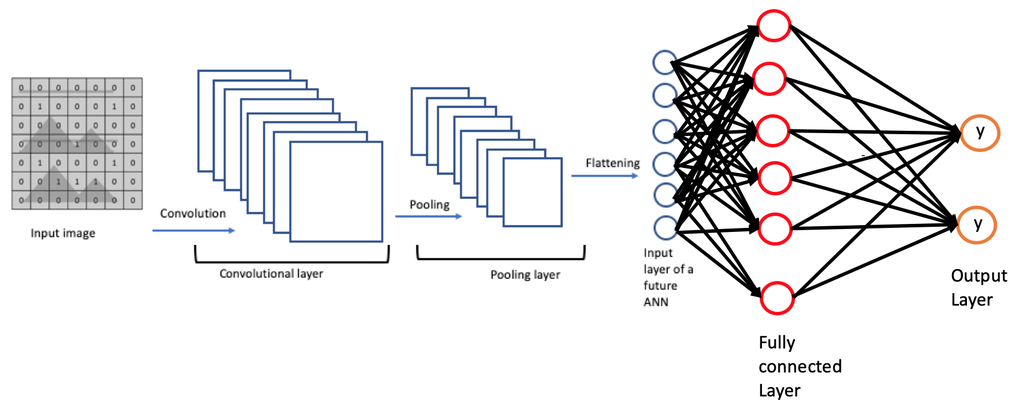

## NOTE:

#### * *FILTERS:* Typical values for the number of filters can be determined by the data set's complexity. So essentially the larger the images, the more variety and the more classes you're trying to classify then the more filters you should have.

#### * Most times people typically pick filter based on powers of 2, for example, 32. However, if you have more complex data like road signs etc. you should be starting with a higher filter value

#### The default STRIDE value is 1 x 1 pixel

# BUILDING THE MODEL

```python
model = Sequential()

## ************* FIRST SET OF LAYERS *************************

# CONVOLUTIONAL LAYER
model.add(Conv2D(filters=32, kernel_size=(4,4),input_shape=(32, 32, 3), activation='relu',))
# POOLING LAYER
model.add(MaxPool2D(pool_size=(2, 2)))

## *************** SECOND SET OF LAYERS ***********************
#Since the shape of the data is 32 x 32 x 3 =3072 ...
#We need to deal with this more complex structure by adding yet another convolutional layer

# *************CONVOLUTIONAL LAYER
model.add(Conv2D(filters=32, kernel_size=(4,4),input_shape=(32, 32, 3), activation='relu',))
# POOLING LAYER
model.add(MaxPool2D(pool_size=(2, 2)))

# FLATTEN IMAGES FROM 32 x 32 x 3 =3072 BEFORE FINAL LAYER
model.add(Flatten())

# 256 NEURONS IN DENSE HIDDEN LAYER (YOU CAN CHANGE THIS NUMBER OF NEURONS)
model.add(Dense(256, activation='relu'))

# LAST LAYER IS THE CLASSIFIER, THUS 10 POSSIBLE CLASSES
model.add(Dense(10, activation='softmax'))


model.compile(loss='categorical_crossentropy',
              optimizer='adam',
              metrics=['accuracy'])
```

```python
model.summary()
```

```
Model: "sequential"
```

```
┏━━━━━━━━━━━━━━━━━━━━━━━━━━━━━━━━━┳━━━━━━━━━━━━━━━━━━━━━━━━┳━━━━━━━━━━━━━━━┓
┃ Layer (type)                    ┃ Output Shape           ┃       Param # ┃
┡━━━━━━━━━━━━━━━━━━━━━━━━━━━━━━━━━╇━━━━━━━━━━━━━━━━━━━━━━━━╇━━━━━━━━━━━━━━━┩
│ conv2d (Conv2D)                 │ (None, 29, 29, 32)     │         1,568 │
├─────────────────────────────────┼────────────────────────┼───────────────┤
│ max_pooling2d (MaxPooling2D)    │ (None, 14, 14, 32)     │             0 │
├─────────────────────────────────┼────────────────────────┼───────────────┤
│ conv2d_1 (Conv2D)               │ (None, 11, 11, 32)     │        16,416 │
├─────────────────────────────────┼────────────────────────┼───────────────┤
│ max_pooling2d_1 (MaxPooling2D)  │ (None, 5, 5, 32)       │             0 │
├─────────────────────────────────┼────────────────────────┼───────────────┤
│ flatten (Flatten)               │ (None, 800)            │             0 │
├─────────────────────────────────┼────────────────────────┼───────────────┤
│ dense (Dense)                   │ (None, 256)            │       205,056 │
├─────────────────────────────────┼────────────────────────┼───────────────┤
│ dense_1 (Dense)                 │ (None, 10)             │         2,570 │
└─────────────────────────────────┴────────────────────────┴───────────────┘
```

```
 Total params: 225,610 (881.29 KB)
```

```
 Trainable params: 225,610 (881.29 KB)
```

```
 Non-trainable params: 0 (0.00 B)
```

### Adding Early stopping

```python
from tensorflow.keras.callbacks import EarlyStopping
```

```python
early_stop = EarlyStopping(monitor='val_loss',patience=2)
```

```python
history = model.fit(x_train,y_cat_train,epochs=25,validation_data=(x_val,y_val_cat),callbacks=[early_stop])
```

```
1250/1250 ━━━━━━━━━━━━━━━━━━━━ 7s 6ms/step - accuracy: 0.3431 - loss: 1.7999 - val_accuracy: 0.5028 - val_loss: 1.3599
1250/1250 ━━━━━━━━━━━━━━━━━━━━ 7s 6ms/step - accuracy: 0.5308 - loss: 1.3117 - val_accuracy: 0.5819 - val_loss: 1.1744
1250/1250 ━━━━━━━━━━━━━━━━━━━━ 7s 6ms/step - accuracy: 0.5963 - loss: 1.1390 - val_accuracy: 0.6050 - val_loss: 1.1153
1250/1250 ━━━━━━━━━━━━━━━━━━━━ 7s 6ms/step - accuracy: 0.6425 - loss: 1.0187 - val_accuracy: 0.6240 - val_loss: 1.0759
1250/1250 ━━━━━━━━━━━━━━━━━━━━ 7s 6ms/step - accuracy: 0.6770 - loss: 0.9240 - val_accuracy: 0.6345 - val_loss: 1.0578
1250/1250 ━━━━━━━━━━━━━━━━━━━━ 7s 6ms/step - accuracy: 0.7095 - loss: 0.8415 - val_accuracy: 0.6465 - val_loss: 1.0570
1250/1250 ━━━━━━━━━━━━━━━━━━━━ 7s 6ms/step - accuracy: 0.7315 - loss: 0.7721 - val_accuracy: 0.6500 - val_loss: 1.0793
1250/1250 ━━━━━━━━━━━━━━━━━━━━ 7s 6ms/step - accuracy: 0.7565 - loss: 0.7038 - val_accuracy: 0.6457 - val_loss: 1.1294
```

```python
model.history.history.keys()
```

```
dict_keys(['accuracy', 'loss', 'val_accuracy', 'val_loss'])
```

```python
metrics = pd.DataFrame(model.history.history)
```

```python
metrics
```

|  | accuracy | loss | val_accuracy | val_loss |
| --- | --- | --- | --- | --- |
| 0 | 0.423425 | 1.589648 | 0.5028 | 1.359900 |
| 1 | 0.551925 | 1.259890 | 0.5819 | 1.174354 |
| 2 | 0.609750 | 1.105711 | 0.6050 | 1.115250 |
| 3 | 0.651500 | 0.993994 | 0.6240 | 1.075921 |
| 4 | 0.684825 | 0.903146 | 0.6345 | 1.057833 |
| 5 | 0.714800 | 0.824628 | 0.6465 | 1.057014 |
| 6 | 0.740950 | 0.751417 | 0.6500 | 1.079320 |
| 7 | 0.762600 | 0.686803 | 0.6457 | 1.129429 |

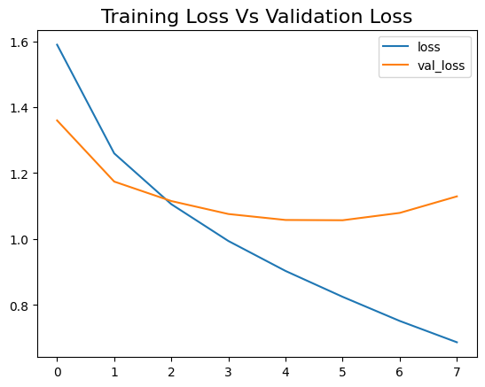

```python
metrics[['loss', 'val_loss']].plot()
plt.title('Training Loss Vs Validation Loss', fontsize=16)
plt.show()
```

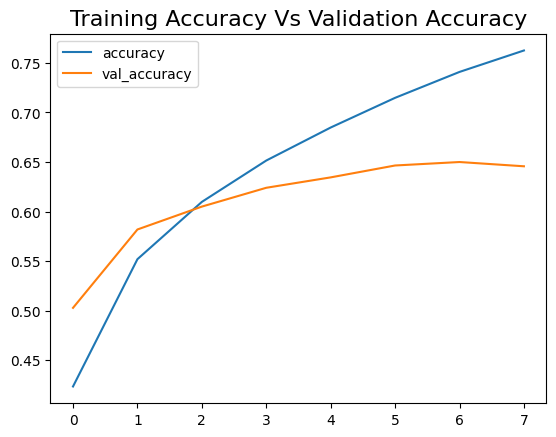

```python
metrics[['accuracy', 'val_accuracy']].plot()
plt.title('Training Accuracy Vs Validation Accuracy', fontsize=16)
plt.show()
```

## Validating on Test Data

```python
model.evaluate(x_test,y_cat_test)
```

```
313/313 ━━━━━━━━━━━━━━━━━━━━ 0s 1ms/step - accuracy: 0.6425 - loss: 1.1171
```

```
[1.1144734621047974, 0.6467000246047974]
```

## Classification Report and Confusion Matrix

```python
from sklearn.metrics import classification_report, confusion_matrix
```

```python
#predictions = model.predict_classes(x_test)
predictions = np.argmax(model.predict(x_test), axis=-1)
```

```
313/313 ━━━━━━━━━━━━━━━━━━━━ 0s 1ms/step
```

```python
print(classification_report(y_test,predictions))
```

```
              precision    recall  f1-score   support

           0       0.74      0.67      0.70      1000
           1       0.77      0.75      0.76      1000
           2       0.57      0.52      0.54      1000
           3       0.41      0.56      0.48      1000
           4       0.54      0.67      0.60      1000
           5       0.59      0.47      0.52      1000
           6       0.77      0.70      0.74      1000
           7       0.68      0.69      0.69      1000
           8       0.79      0.72      0.75      1000
           9       0.71      0.71      0.71      1000

    accuracy                           0.65     10000
   macro avg       0.66      0.65      0.65     10000
weighted avg       0.66      0.65      0.65     10000
```

```python
confusion_matrix(y_test,predictions)
```

```
array([[666,  26,  61,  39,  26,  16,  14,  16,  84,  52],
       [ 22, 753,  11,  24,   6,   7,  14,   9,  38, 116],
       [ 45,   7, 518, 112, 159,  41,  52,  39,  18,   9],
       [ 11,  10,  53, 562, 106, 143,  42,  50,   7,  16],
       [ 14,   4,  76,  92, 666,  30,  36,  70,   9,   3],
       [ 14,   4,  58, 260,  72, 475,  22,  86,   2,   7],
       [  6,   6,  61, 110,  73,  19, 704,  12,   2,   7],
       [ 15,  10,  27,  77,  97,  60,   6, 692,   3,  13],
       [ 75,  49,  25,  42,  10,  10,   6,   3, 717,  63],
       [ 26, 105,  21,  38,  10,  10,  14,  36,  26, 714]])
```

# Predicting on single image

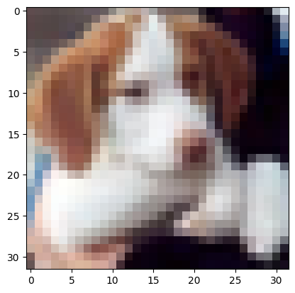

```python
plt.imshow(x_test[16])
```

```python
my_image = x_test[16]
```

```python
# SHAPE --> (num_images,width,height,color_channels)
preds = model.predict(my_image.reshape(1,32,32,3))
label = np.argmax(preds, axis=1)[0]

print(label)
```

[output not shown]

```python
LABEL_NAMES[y_test[16][0]]
```

```
'dog'
```

## Solution

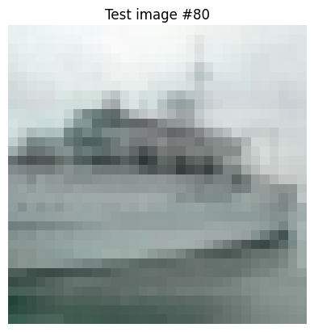

[output not shown]

```python
import numpy as np
import matplotlib.pyplot as plt

# ─── AFTER you have already loaded & normalized x_test and y_test,
# ─── and after you have built & trained “model” ─────────────────────

# Change this index to any value 0–9999 (or 1–15 as you asked)
INDEX_CHOICE = 80

# 1) Show the chosen test image
plt.imshow(x_test[INDEX_CHOICE])
plt.axis('off')
plt.title(f"Test image #{INDEX_CHOICE}")
plt.show()

# 2) Run the model’s prediction on exactly that one image
probs = model.predict(x_test[INDEX_CHOICE].reshape(1, 32, 32, 3))

# 3) Convert to a single integer class via argmax
predicted_index = np.argmax(probs, axis=1)[0]
true_index      = y_test[INDEX_CHOICE][0]    # if y_test was shape (10000,1)

# 4) (Optional) If you want human-readable labels for CIFAR-10:
label_names = ['airplane', 'automobile', 'bird', 'cat', 'deer',
               'dog', 'frog', 'horse', 'ship', 'truck']

print(f"Predicted class index: {predicted_index} “{label_names[predicted_index]}”")
print(f"True      class index: {true_index} “{label_names[true_index]}”")
print("Correct?" , "→ Yes ✔" if (predicted_index == true_index) else "→ No ✘")
```